# Predicting barbell lifts activity

Christopher Jung

23 August 2016

## Background

Using devices such as Jawbone Up, Nike FuelBand, and Fitbit it is now possible to collect a large amount of data about personal activity relatively inexpensively. These type of devices are part of the quantified self movement - a group of enthusiasts who take measurements about themselves regularly to improve their health, to find patterns in their behavior, or because they are tech geeks. One thing that people regularly do is quantify how much of a particular activity they do, but they rarely quantify how well they do it.

In this project, we will use data from accelerometers on the belt, forearm, arm, and dumbell of 6 participants to predict whether barbell lifts were performed correctly (across 5 different types of error classifications).

More information is available from the website here: http://groupware.les.inf.puc-rio.br/har (see the section on the Weight Lifting Exercise Dataset).

## Getting the data

First we downloaded the data.

```r
## download the data
url_train <- "https://d396qusza40orc.cloudfront.net/predmachlearn/pml-training.csv"
dest_train <- "D:/Users/80027138/Data/Coursera/training.csv"

url_test <- "https://d396qusza40orc.cloudfront.net/predmachlearn/pml-testing.csv"
dest_test <- "D:/Users/80027138/Data/Coursera/testing.csv"

if(!file.exists(dest_train)) download.file(url = url_train , destfile = dest_train)
if(!file.exists(dest_test)) download.file(url = url_test , destfile = dest_test)
```

We then loaded the data into R.

```r
## load the csv files
training <- read.csv(file =dest_train, header = TRUE, na.strings = c("NA",""))
testing <- read.csv(file =dest_test, header = TRUE, na.strings = c("NA",""))
```

## Basic data cleaning

Before carrying out the analysis, we performed some basic data cleaning, such as removing columns with NA’s and getting rid of unwanted columns (as they are meta-data rather than recorded data).

First we note that some columns seem to have mostly NA values in them (approx. 98% of values).

```r
## get the percentage of NA's per column
colSums(is.na(training))/nrow(training)
```

```
##                        X                user_name     raw_timestamp_part_1
##                0.0000000                0.0000000                0.0000000
##     raw_timestamp_part_2           cvtd_timestamp               new_window
##                0.0000000                0.0000000                0.0000000
##               num_window                roll_belt               pitch_belt
##                0.0000000                0.0000000                0.0000000
##                 yaw_belt         total_accel_belt       kurtosis_roll_belt
##                0.0000000                0.0000000                0.9793089
##      kurtosis_picth_belt        kurtosis_yaw_belt       skewness_roll_belt
##                0.9793089                0.9793089                0.9793089
##     skewness_roll_belt.1        skewness_yaw_belt            max_roll_belt
##                0.9793089                0.9793089                0.9793089
##           max_picth_belt             max_yaw_belt            min_roll_belt
##                0.9793089                0.9793089                0.9793089
##           min_pitch_belt             min_yaw_belt      amplitude_roll_belt
##                0.9793089                0.9793089                0.9793089
##     amplitude_pitch_belt       amplitude_yaw_belt     var_total_accel_belt
##                0.9793089                0.9793089                0.9793089
##            avg_roll_belt         stddev_roll_belt            var_roll_belt
##                0.9793089                0.9793089                0.9793089
##           avg_pitch_belt        stddev_pitch_belt           var_pitch_belt
##                0.9793089                0.9793089                0.9793089
##             avg_yaw_belt          stddev_yaw_belt             var_yaw_belt
##                0.9793089                0.9793089                0.9793089
##             gyros_belt_x             gyros_belt_y             gyros_belt_z
##                0.0000000                0.0000000                0.0000000
##             accel_belt_x             accel_belt_y             accel_belt_z
##                0.0000000                0.0000000                0.0000000
##            magnet_belt_x            magnet_belt_y            magnet_belt_z
##                0.0000000                0.0000000                0.0000000
##                 roll_arm                pitch_arm                  yaw_arm
##                0.0000000                0.0000000                0.0000000
##          total_accel_arm            var_accel_arm             avg_roll_arm
##                0.0000000                0.9793089                0.9793089
##          stddev_roll_arm             var_roll_arm            avg_pitch_arm
##                0.9793089                0.9793089                0.9793089
##         stddev_pitch_arm            var_pitch_arm              avg_yaw_arm
##                0.9793089                0.9793089                0.9793089
##           stddev_yaw_arm              var_yaw_arm              gyros_arm_x
##                0.9793089                0.9793089                0.0000000
```

[output cut: 53 more lines]

```
##                0.9793089                0.0000000                0.9793089
##         avg_roll_forearm      stddev_roll_forearm         var_roll_forearm
##                0.9793089                0.9793089                0.9793089
##        avg_pitch_forearm     stddev_pitch_forearm        var_pitch_forearm
##                0.9793089                0.9793089                0.9793089
##          avg_yaw_forearm       stddev_yaw_forearm          var_yaw_forearm
##                0.9793089                0.9793089                0.9793089
##          gyros_forearm_x          gyros_forearm_y          gyros_forearm_z
##                0.0000000                0.0000000                0.0000000
##          accel_forearm_x          accel_forearm_y          accel_forearm_z
##                0.0000000                0.0000000                0.0000000
##         magnet_forearm_x         magnet_forearm_y         magnet_forearm_z
##                0.0000000                0.0000000                0.0000000
##                   classe
##                0.0000000
```

We removed these columns for the analysis.

```r
## get the index of all cols with NA's
isna <- which(colSums(is.na(training))/nrow(training) >0)

## remove the columns with mostly NA's from train and test data
train <- training[,-isna]
test  <- testing[,-isna]
```

A number of variables in the data describe the user rather than being measutrements of the activity. These variables were excluded from the data.

```r
## define further columns to remove as they constitute metadata
## these will not be used in the prediction model
ismetadata <- c("X",
                "user_name",
                "raw_timestamp_part_1",
                "raw_timestamp_part_2", "cvtd_timestamp",
                "new_window",
                "num_window")

## remove the unnecessary columns
train <- train[,!names(train) %in% ismetadata]
test  <- test[,!names(test) %in% ismetadata]
```

## Creating a validation set

To cross validate our model we created a validation set.

```r
## create a validation set
library(caret)
set.seed(080782)
intrain <- createDataPartition(y = train$classe, p = .7, list=FALSE)
valid <- train[-intrain, ]
train <- train[intrain, ]
```

The resulting datasets had 53 variables, of which 52 are measurement variables and one is the `classe` variable. The training set had a total sample of 13,737, the validation set 5,885, and the straining set 20.

```r
## get the sample sizes
dim(train)
```

```
## [1] 13737    53
```

```r
dim(valid)
```

```
## [1] 5885   53
```

```r
dim(test)
```

```
## [1] 20 53
```

## Variable correlation

Before running the model, we looked at the correlation of the vairables.

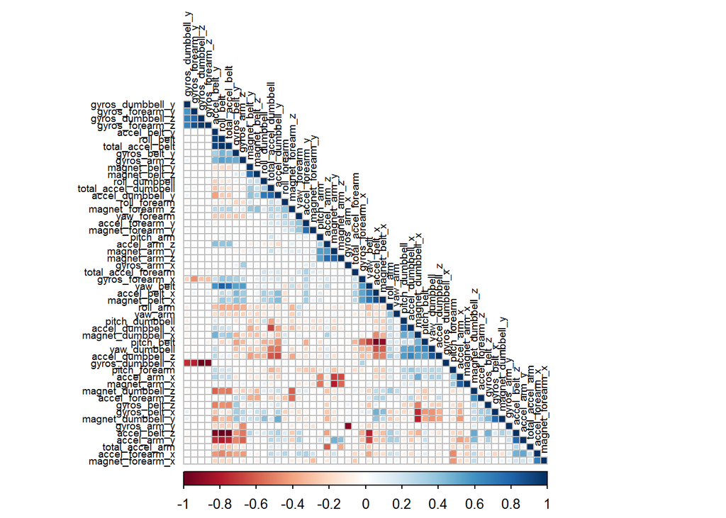

```r
# plot the correlations between variables
library(corrplot)
i <- which(names(train) == c("classe"))
cormatrix <- cor(train[,-i])
corrplot(cormatrix,
         method="square",
         order = "hclust",
         type = "lower",
         tl.cex = .6,
         tl.col = 1)
```

By looking at the correlation plt it became quite apparent that some variables seem highly correlated.

## Variable reduction

As we have a lot of variables with some of them correlated, an obvious choice is to reduce the variable set using principal component analysis, which should lead to only a minor loss of information. For the purpose of this excercise we set the PCA to explain 90% of the variance in the data.

```r
# run a principal component analysis
pca <- preProcess(train[,-i], method = "pca", thresh =.90)
```

We then applied the variable reduction to the test, validation and training sets.

```r
#apply the pca to the training and validation set
trainPCA <- predict(pca, train[,-i])
trainPCA$classe <- train$classe
validPCA <- predict(pca, valid[,-i])
validPCA$classe <- valid$classe
testPCA <- predict(pca, test[,-i])
testPCA$classe <- test$classe
```

## Running the prediction algorithm

With a reduced dataset, we performed a random forest prediction model. Random forsts tend to produce very accurate results, and as our dataset has been reduced through PCA, the algorithm does not run for too long.

We used the cross validation method to reduce the time it takes to run the model.

```r
## run the random forests prediction algorithm
model <- train(classe~ .,
                data=trainPCA,
                method="rf",
                trControl = trainControl(method = "cv", number = 5))
```

## Cross validation

To estimate the out of sample error we used the validation set we created.

```r
validPredict <- predict(model, validPCA)
conf <- confusionMatrix(validPCA$classe, validPredict)
conf
```

```
## Confusion Matrix and Statistics
##
##           Reference
## Prediction    A    B    C    D    E
##          A 1660    3    6    5    0
##          B   15 1101   21    1    1
##          C    1   17  992   16    0
##          D    1    2   38  922    1
##          E    0    2    6    5 1069
##
## Overall Statistics
##
##                Accuracy : 0.976
##                  95% CI : (0.9718, 0.9798)
##     No Information Rate : 0.285
##     P-Value [Acc > NIR] : < 2.2e-16
##
##                   Kappa : 0.9697
##  Mcnemar's Test P-Value : NA
##
## Statistics by Class:
##
##                      Class: A Class: B Class: C Class: D Class: E
## Sensitivity            0.9899   0.9787   0.9332   0.9715   0.9981
## Specificity            0.9967   0.9920   0.9929   0.9915   0.9973
## Pos Pred Value         0.9916   0.9666   0.9669   0.9564   0.9880
## Neg Pred Value         0.9960   0.9949   0.9854   0.9945   0.9996
## Prevalence             0.2850   0.1912   0.1806   0.1613   0.1820
## Detection Rate         0.2821   0.1871   0.1686   0.1567   0.1816
## Detection Prevalence   0.2845   0.1935   0.1743   0.1638   0.1839
## Balanced Accuracy      0.9933   0.9853   0.9631   0.9815   0.9977
```

```r
accur <- postResample(validPCA$classe, validPredict)[[1]]
accur
```

```
## [1] 0.9760408
```

Our analysis showed that the expected accuracy of the model is of 97.6% - or an out of sample eror of approx. 2.4%.

## Predicting values

We then used the test set of 20 observations to predict the classe variable.

```r
## apply the prediction algorithm to the test data
predict(model, predict(pca, test[,-i]))
```

```
##  [1] B A B A A E D B A A B C B A E E A B B B
## Levels: A B C D E
```